# ICL maximisation for discrete latent variable models

Etienne Côme

23 mai 2019

## Abstract

## Introduction

Model based clustering is a principled approach for clustering (Fraley and Raftery 2002), that has already proved to be very useful in a variety of context thanks to it’s capability of dealing with particular data structure. Such approaches encompasses to name a few: Gaussian mixture models, mixture of regression and graph clustering models like stochastic block models. In their basic form such models assume that the observations $\{x_1,...x_n\}$ are drawn from a two step process, first a discrete latent variable is drawn using a multinomial distribution (with proportions $\pi$), then conditionally on the drawn cluster an observation is sampled using the cluster own distribution. More formally, this can be written as:

$$\begin{eqnarray}
\mathbf{z}_i|\pi&\sim& \mathcal{M}(1,\pi)\\
x_i|\mathbf{z}_{ik}=1,\theta_{k}&\sim& \mathcal{F}(\theta_{k}),
\end{eqnarray}$$

where the $\mathbf{z}_i\in\{0,1\}^K$ is the so-called latent variable encoding cluster membership. From a computational perspective there are two main way to deal with such type of models. From a frequentist perspective, if the main focus is in estimating the data distribution to integrate out the latent variable and look for the $\theta$ that maximize the likelihood:

$$\begin{eqnarray}
L(\theta_1,...,\theta_K)=\prod_{i=1}^N\sum_{k=1}^{K}\pi_k f(x_i;\theta_k),
\end{eqnarray}$$
where f is the density of the mixtures component distributions. Such functional forms are not easy to optimize but the well known EM algorithm (Dempster, Laird, and Rubin 1977) is a natural solution to this problem when the latent variable are independents given the observations. When this is not the case one may resorts to variational approximations (Jordan et al. 1999) to solve the optimization problem. These type of approaches converge to a local maximum of the likelihood and require the number of cluster to be fixed. When the number of groups $K$ is unknown, one classically try several values and resorts to model selection criteria like BIC and AIC (McLachlan and Peel 2000) to find the best fitting model given the data at hands. These solution leads typically to algorithms with complexity $\mathcal{O}(NK^2d)$ where $d$ is the number of features.

Always from a frequentist perspective when the main goal is to recovers the latent variable states one may keep them in the optimization problem and try to maximize the complete data likelihood with respect to both the latent variables states and the distributions parameters. This leads to the Classification EM algorithm (Celeux and Govaert 1992) which generalize the K-means algorithm (which corresponds to the special case of a mixture of spherical Gaussian with equal proportions). Such solution leads to algorithm with the same complexity as a classical EM even if they may converge more quickly. Such approaches also leave open the question of model selection (with respect to the number of mixture component), but a in the same spirit as the Classification EM algorithm, one may try to use an approximate version of the so called integrated classification likelihood criterion (ICL). Which correspond to a BIC like approximation of the integrated classification likelihood with improper but non informative prior.

$$p(X,Z) = \int_{\theta}\int_{\pi}p(x|z,\theta)p(\theta)p(z|\pi)p(\pi)d\theta d\pi$$

Note that ICL was originally proposed by Biernacki, Celeux and Govaert (Biernacki, Celeux, and Govaert 2000) for Gaussian mixture models. It was then adapted by Biernacki, Celeux and Govaert (Biernacki, Celeux, and Govaert 2010) to mixtures of multivariate multinomial distributions and to the SBM model by Daudin, Picard and Robin (Daudin, Picard, and Robin 2008).

From a Bayesian perspective a natural way to deals with finite mixture model come from MCMC sampling which can be used to sample both latent variables values and parameters according to the posterior distribution. In such setting, the mixture model is complemented with prior distributions over parameters $(\pi,\theta_1,...,\theta_k)$, which are often chose to be conjugate. A Dirichlet distribution being used as prior for the latent variables. This leads to the following type of models:

$$\begin{eqnarray}
\pi&\sim& \mathcal{D}(\mathbf{\alpha})\\
\mathbf{z}_i|\pi&\sim& \mathcal{M}(1,\pi)\\
\theta_{k}&\sim& P(\mathbf{\beta})\\
x_i|\mathbf{z}_{ik}=1,\theta_k&\sim& \mathcal{F}(\theta_{k})
\end{eqnarray}$$

with $\mathcal{D}(\alpha)$ the Dirichlet distribution of parameter $\alpha$ and $P(\beta)$ a prior distribution for the $\theta$’s. Using Gibbs sampling (Diebolt and P. 1994) or variant one may obtain sample from the posterior distribution. However, sampling can be hard with difficulty to explore the different modes of the posterior distribution. Exploration of the posterior samples can also be hard to perform due to the label switching problem (Diebolt and P. 1994,Stephens (2000)) and even difficulties in retrieving the more plausible latent variable state (Rastelli and Friel 2018). For a more complete discussion of these different approaches and a complete state of the art on these problem see (Celeux, Fruewirth-Schnatter, and Robert 2018).

```r
N=1500
K=15
pi=rep(1/K,K)
lambda  = 0.1
lambda_o = 0.025
Ks=5
mu = bdiag(lapply(1:(K/Ks), function(k){matrix(lambda_o,Ks,Ks)+diag(rep(lambda,Ks))}))+0.001
sbm = rsbm(N,pi,mu)
```

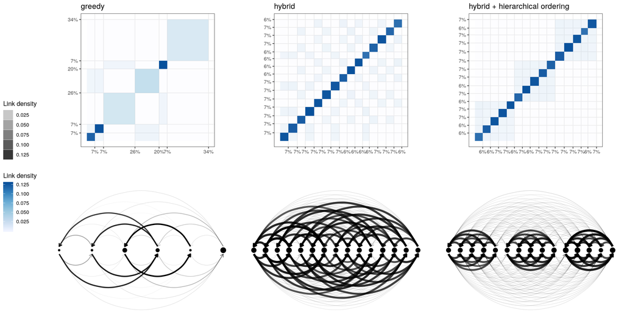

Motivating example of the porposed algorithm.

### Models and criterions

#### Mixture of multinomial

#### Mixture of regression with gaussian mixture as special case

#### Stochastick block models and it’s degree corected version

### Optimization Algorithms

### Regularisation path and hierarchical clustering

## Related works and conclusions

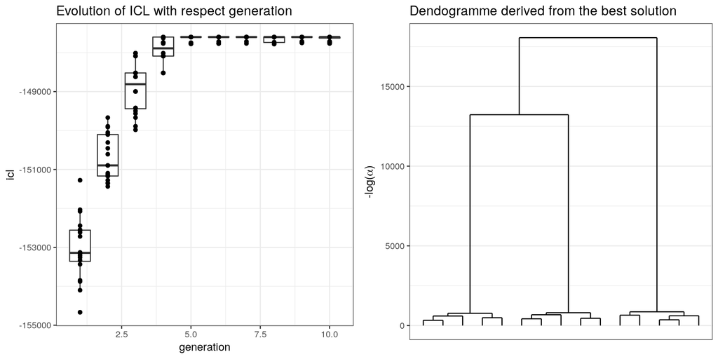

```r
Nbsim = 10
S=matrix(0,1500,Nbsim)
Fi=matrix(0,1500,Nbsim)
Fi_o=matrix(0,1500,Nbsim)
Fi_s=matrix(0,1500,Nbsim)
Fi_si=matrix(0,1500,Nbsim)
Fi_ms=matrix(0,1500,Nbsim)
Xlist = list()
for (s in 1:Nbsim){
  N=1500
  K=15
  pi=rep(1/K,K)
  lambda  = 0.1
  lambda_o = 0.025
  Ks=5
  mu = bdiag(lapply(1:(K/Ks), function(k){matrix(lambda_o,Ks,Ks)+diag(rep(lambda,Ks))}))+0.001
  sbm = rsbm(N,pi,mu)
  S[,s]=sbm$cl
  Xlist[[s]]=sbm
  fit = greed(sbm$x,model=new("sbm"),alg = new("hybrid",pop_size=50))
  Fi[,s]=fit@cl
  fit_o = greed::fit_greed(new("sbm"),list(X=sbm$x),sample(1:20,nrow(sbm$x),replace = TRUE))
  Fi_o[,s] = fit_o@cl
  cl=spectral(sbm$x,15)
  Fi_s[,s] = cl
  fit_sp_init=greed(sbm$x,model=new("sbm"),alg=new("seed"))
  Fi_si[,s] = fit_sp_init@cl
  fit_ms = greed(sbm$x,model=new("sbm"),alg = new("multistarts",nb_start=50))
  Fi_ms[,s]=fit_ms@cl
}
```

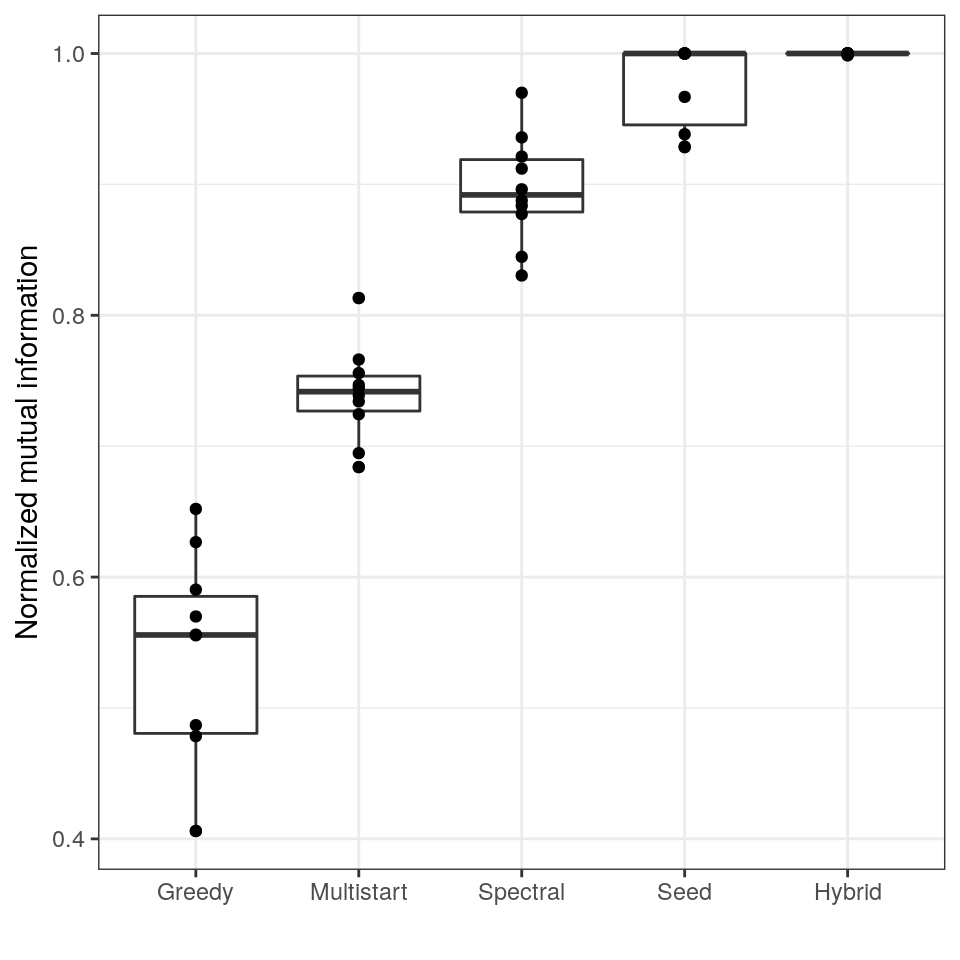

### Real data

```r
data("Blogs")
fit_blogs = greed(Blogs$X,model=new("dcsbm"))
data("Books")
fit_books = greed(Books$X,model=new("dcsbm"))
data("Football")
fit_foot = greed(Football$X,model=new("dcsbm"))
data("Jazz")
fit_jazz = greed(Jazz,model=new("dcsbm"))
```

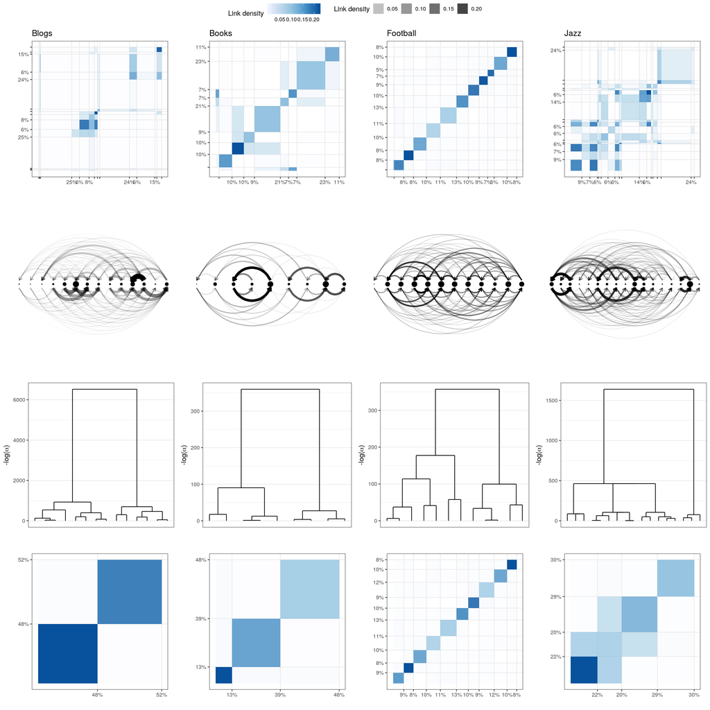

## Conclusion

## References

Bertoletti, Marco, Nial Friel, and Riccardo Rastelli. 2015. “Choosing the Number of Clusters in a Finite Mixture Model Using an Exact Integrated Completed Likelihood Criterion.” *METRON* 73 (2): 177–99. doi:10.1007/s40300-015-0064-5.

Biernacki, Christophe, Gilles Celeux, and Gerard Govaert. 2000. “Assessing a Mixture Model for Clustering with the Integrated Completed Likelihood.” *IEEE Transaction on Pattern Analysis and Machine Intelligence* 7: 719–25.

———. 2010. “Exact and Monte Carlo Calculations of Integrated Likelihoods for the Latent Class Model.” *Journal of Statistical Planning and Inference* 140: 2991–3002.

Celeux, Gilles, and Gerard Govaert. 1992. “A Classification Em Algorithm for Clustering and Two Stochastic Versions.” *Computational Statistics & Data Analysis* 14 (3): 315–32. https://EconPapers.repec.org/RePEc:eee:csdana:v:14:y:1992:i:3:p:315-332.

Celeux, Gilles, Sylvia Fruewirth-Schnatter, and Christian P. Robert. 2018. “Model Selection for Mixture Models - Perspectives and Strategies.” *arXiv E-Prints*, December, arXiv:1812.09885.

Corneli, Marco, Pierre Latouche, and Fabrice Rossi. 2016. “Exact Icl Maximization in a Non-Stationary Temporal Extension of the Stochastic Block Model for Dynamic Networks.” *Neurocomputing* 192: 81–91. doi:https://doi.org/10.1016/j.neucom.2016.02.031.

Côme, Etienne, and Pierre Latouche. 2015. “Model Selection and Clustering in Stochastic Block Models Based on the Exact Integrated Complete Data Likelihood.” *Statistical Modelling* 15 (6): 564–89. doi:10.1177/1471082X15577017.

Daudin, J., F. Picard, and S. Robin. 2008. “A Mixture Model for Random Graph.” *Statistics and Computing* 18: 1–36.

Dempster, A. P., N. M. Laird, and D. B. Rubin. 1977. “Maximum Likelihood from Incomplete Data via the Em Algorithm.” *Journal of the Royal Statistical Society. Series B (Methodological)* 39 (1). [Royal Statistical Society, Wiley]: 1–38. http://www.jstor.org/stable/2984875.

Diebolt, J., and Robert C. P. 1994. “Estimation of Finite Mixture Distributions Through Bayesian Sampling.” *Journal of the Royal Statistical Society B* 56: 363–75.

Fraley, Chris, and Adrian E Raftery. 2002. “Model-Based Clustering, Discriminant Analysis, and Density Estimation.” *Journal of the American Statistical Association* 97 (458). Taylor & Francis: 611–31. doi:10.1198/016214502760047131.

Jordan, Michael I., Zoubin Ghahramani, Tommi S. Jaakkola, and Lawrence K. Saul. 1999. “An Introduction to Variational Methods for Graphical Models.” *Mach. Learn.* 37 (2). Hingham, MA, USA: Kluwer Academic Publishers: 183–233. doi:10.1023/A:1007665907178.

McLachlan, Geoffrey, and David Peel. 2000. *Finite Mixture Models*. John Wiley & Sons, Inc. doi:10.1002/0471721182.

Rastelli, Riccardo, and Nial Friel. 2018. “Optimal Bayesian Estimators for Latent Variable Cluster Models.” *Statistics and Computing* 28 (6): 1169–86. doi:10.1007/s11222-017-9786-y.

Stephens, Matthew. 2000. “Dealing with Label Switching in Mixture Models.” *Journal of the Royal Statistical Society B* 62 (4): 795–809.

Zreik, Rawya, Pierre Latouche, and Charles Bouveyron. 2017. “The Dynamic Random Subgraph Model for the Clustering of Evolving Networks.” *Computational Statistics* 32 (2): 501–33. doi:10.1007/s00180-016-0655-5.